# Chicken Feed

Alexandra Shields-Knox

03/05/2020

## Chicken feed study

data set has chicken weights and 4 variables: 1. chicken weight  
2. chicken feed type  
3. chicken time in the 40" run  
4. chicken sex

Idea is to determine which of the variables affect chicken weight The weight and time to run are numerical variables, gender and feed type are categorical variables

So we’ll use templatesRMD Cat Numerical, look for the section that has an ‘aov’

### get the data

```r
chickenData = read.csv('chickens.csv')
head(chickenData)
```

```
##   X weight      feed    speed sex
## 1 1    179 horsebean 146.4784   f
## 2 2    160 horsebean 153.0091   f
## 3 3    136 horsebean 103.3579   f
## 4 4    227 horsebean 120.5125   m
## 5 5    217 horsebean 153.0779   f
## 6 6    168 horsebean 105.2664   f
```

```r
attach(chickenData)
```

### Graphical summary

Boxplot of weight based on feed

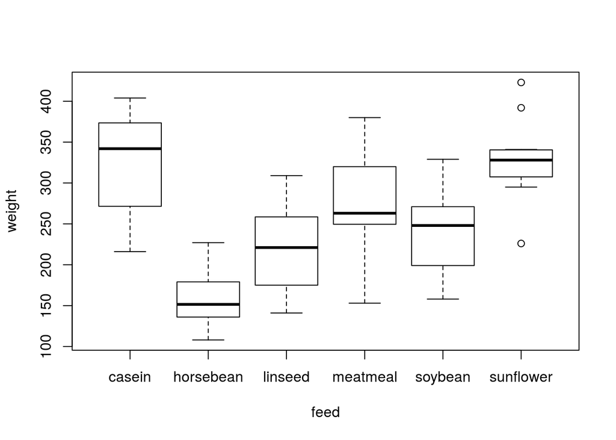

```r
plot(weight~feed,data=chickenData)
```

It appears that type of feed does have an effect on weight. Sunflower appears to be the best because of the lowest variability.

Boxplot of weight based on sex

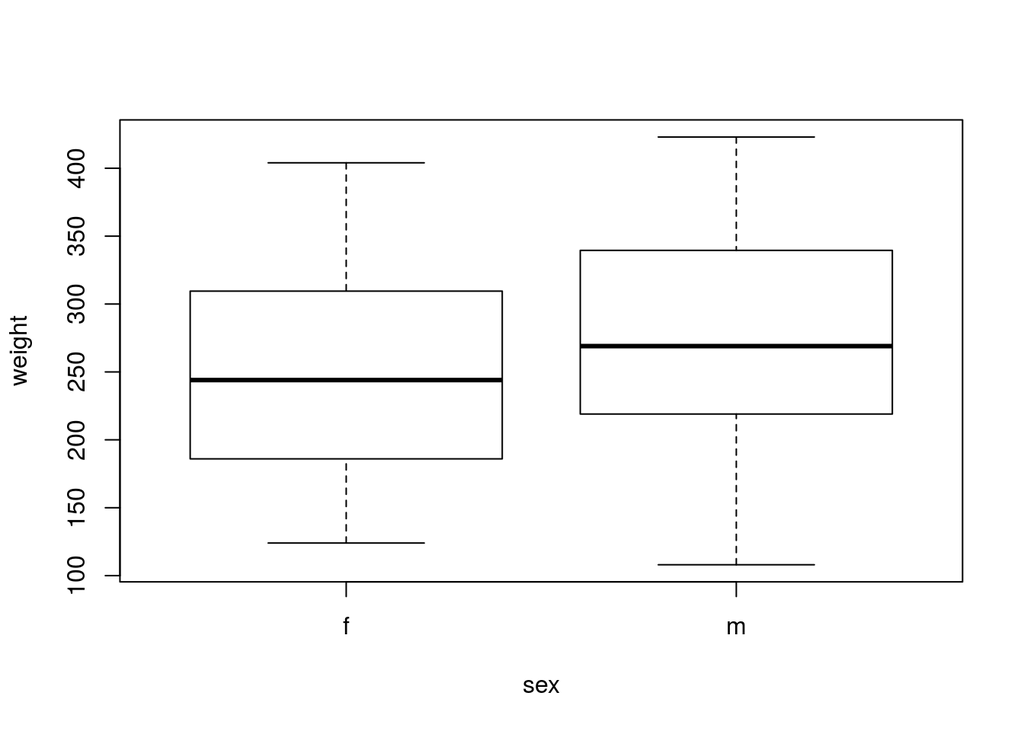

```r
plot(weight~sex,data=chickenData)
```

It appears that male chickens weight slightly more than female chickens on average.

Scatterplot of weight based on speed

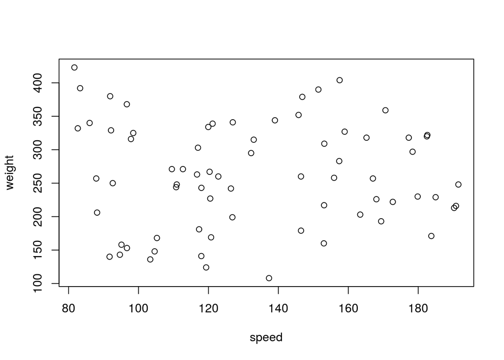

```r
plot(weight~speed,data=chickenData)
```

Speed does not appear to have any relationship to weight of the chicken.

### Numerical summary

```r
summary(chickenData)
```

```
##        X            weight             feed        speed        sex
##  Min.   : 1.0   Min.   :108.0   casein   :12   Min.   : 81.66   f:35
##  1st Qu.:18.5   1st Qu.:204.5   horsebean:10   1st Qu.:104.94   m:36
##  Median :36.0   Median :258.0   linseed  :12   Median :126.43
##  Mean   :36.0   Mean   :261.3   meatmeal :11   Mean   :132.58
##  3rd Qu.:53.5   3rd Qu.:323.5   soybean  :14   3rd Qu.:158.24
##  Max.   :71.0   Max.   :423.0   sunflower:12   Max.   :191.50
```

This is a summary of all of the data in chickenData

### Inference – Analysis of Variance

```r
model1 = lm(weight~feed+speed+sex, data=chickenData)
anova(model1)
```

```
## Analysis of Variance Table
##
## Response: weight
##           Df Sum Sq Mean Sq F value    Pr(>F)
## feed       5 231129   46226  15.501 6.377e-10 ***
## speed      1   7306    7306   2.450    0.1225
## sex        1    379     379   0.127    0.7228
## Residuals 63 187871    2982
## ---
## Signif. codes:  0 '***' 0.001 '**' 0.01 '*' 0.05 '.' 0.1 ' ' 1
```

The variance table shows that only feed affects chicken weight.

### Conclusions – which variables affect chicken weight?

It appears that feed was the only variable that had any effect on chicken weight.